# Practical Machine Learning Assignment

Michael Lawson

2 March 2018

## Introduction

The goal of this work is to predict the manner in which a group of individuals preformed a barbell lift based on the response of wearable accelerometers. More information is available from the following website: -

http://web.archive.org/web/20161125212224/http://groupware.les.inf.puc-rio.br:80/work.jsf?p1=10335

### Importing Data

```r
setwd('C:/Users/Mike/Desktop/PracticalMachineLearning')
trainingdata <- read.csv('pml-training.csv')
PredSet <- read.csv('pml-testing.csv')
inTrain <- createDataPartition(trainingdata$classe, p = 3/4)[[1]]
training <- trainingdata[inTrain,]
predictor_cols <- colSums(is.na(training)) == 0
training <-training[,predictor_cols]
testing <- trainingdata[-inTrain,]
testing <- testing[,predictor_cols]
```

There’s still a fair few variables, and a few things that we definitely don’t want to predict on, like “X” which is the sample ID. We can remove columns that have the lowest variance, and therefore are expected to give weaker predictions using the “nearZeroVar” function. In the following code we apply this function to reduce the number of predictors <50, by adjusting the “freqCut” variable through trial and error.

```r
nzv_data <- nearZeroVar(training, freqCut = 54/48, saveMetrics = T)
nzv_cols <- nearZeroVar(training, freqCut = 54/48)
```

It’s worth noting filtering the columns this way actually removes the classe variable, the very thing we are trying to predict. We should put it back in after we’ve finished removing the lowest variance columns.

```r
training <- training[,-nzv_cols]
testing <- testing[,-nzv_cols]

training$classe <- trainingdata[inTrain,]$classe
```

Lets begin by trying out a regression tree and seeing how well it does on the test set.

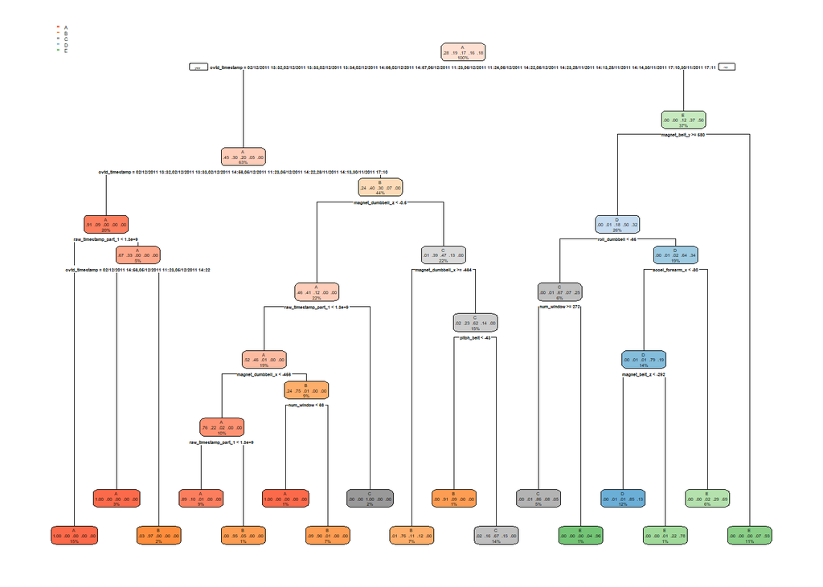

```
## [1] "My regression tree accuracy is 0.862561174551387 ."
```

86.26 % seems fairly reasonably, certainly better than would be expected by chance. We will probably be able to do better if we create an ensemble using multiple predictions methods. Next we shall try a gradient boosted mode: -

```
## [1] "My GBM accuracy is 0.996941272430669 ."
```

The GBM model is significantly better than the regression tree model with an accuracy of 99.69 % on the testing dataset. All things being equal, we would expect similar performance on the out-of-sample test set. With this level of accuracy it is not really necessary to ensemble models to achieve 20/20 correct answers in a validation set. Doing so would make the model more complicated and potentially more fragile.

Here are the predictions for the out of sample data: -

```
##  [1] B A B A A E D B A A B C B A E E A B B B
## Levels: A B C D E
```